# Machine Learning Project

Bindu Shah

## Overview

This project is centerd on HAR (Human Actvity Recognition).

It uses the Weight Lifting Exercises Dataset from the following website: http://groupware.les.inf.puc-rio.br/har

Background information obtained from the above-mentioned website.

“This human activity recognition research has traditionally focused on discriminating between different activities, i.e. to predict”which" activity was performed at a specific point in time (like with the Daily Living Activities dataset above). The approach we propose for the Weight Lifting Exercises dataset is to investigate “how (well)” an activity was performed by the wearer. The “how (well)” investigation has only received little attention so far, even though it potentially provides useful information for a large variety of applications,such as sports training.

Six young health participants were asked to perform one set of 10 repetitions of the Unilateral Dumbbell Biceps Curl in five different fashions: exactly according to the specification (Class A), throwing the elbows to the front (Class B), lifting the dumbbell only halfway (Class C), lowering the dumbbell only halfway (Class D) and throwing the hips to the front (Class E).“”

## Load Training and Test data sets

```r
library(caret)
```

```r
training = read.csv("https://d396qusza40orc.cloudfront.net/predmachlearn/pml-training.csv")

testing = read.csv("https://d396qusza40orc.cloudfront.net/predmachlearn/pml-testing.csv")

dim(training)
```

```
## [1] 19622   160
```

```r
dim(testing)
```

```
## [1]  20 160
```

## Exploratory Data Analysis

```r
nzv <- nearZeroVar(training)
TidyTrain<-training[,-nzv]

na<- sapply(TidyTrain, function(x) mean(is.na(x))) > 0.95
TidyTrain<-TidyTrain[, na==F]


TidyTrain<- TidyTrain[-c(grep("^raw_timestamp|^cvtd_timestamp|^new_window|^num_window|^user_name|X", names(TidyTrain)))]
dim(TidyTrain)
```

```
## [1] 19622    53
```

After eliminating anomalous and unnecessary columns, we have 1 outcome and 52 predictors left.

I picked the Random Forest model with a k-fold cross-validation of 3. I selected Random Forests since it performs implicit feature selection.

## Fit the model on training set

```r
Foldcv<-trainControl(method="cv", verbose=F, number =3)
FitRF<-train(classe~., data=TidyTrain, method="rf", trControl=Foldcv)
FitRF
```

```
## Random Forest
##
## 19622 samples
##    52 predictor
##     5 classes: 'A', 'B', 'C', 'D', 'E'
##
## No pre-processing
## Resampling: Cross-Validated (3 fold)
## Summary of sample sizes: 13081, 13081, 13082
## Resampling results across tuning parameters:
##
##   mtry  Accuracy   Kappa
##    2    0.9927633  0.9908453
##   27    0.9929671  0.9911032
##   52    0.9850170  0.9810455
##
## Accuracy was used to select the optimal model using  the largest value.
## The final value used for the model was mtry = 27.
```

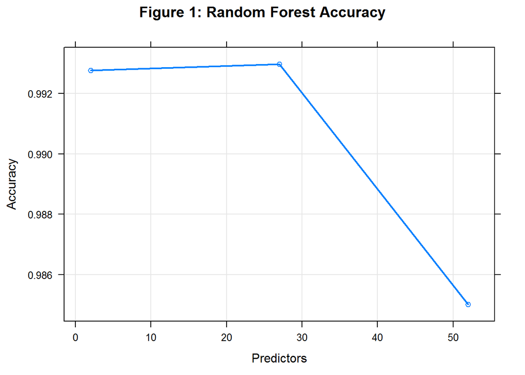

```r
# plot the random forest model
plot(FitRF, lwd = 2, main = "Figure 1: Random Forest Accuracy", xlab = "Predictors", ylab = "Accuracy")
```

## Out of Sample Error Rate

```r
FitRF$finalModel
```

```
##
## Call:
##  randomForest(x = x, y = y, mtry = param$mtry)
##                Type of random forest: classification
##                      Number of trees: 500
## No. of variables tried at each split: 27
##
##         OOB estimate of  error rate: 0.44%
## Confusion matrix:
##      A    B    C    D    E class.error
## A 5574    4    1    0    1 0.001075269
## B   20 3772    5    0    0 0.006584145
## C    0   11 3400   11    0 0.006428989
## D    0    0   21 3192    3 0.007462687
## E    0    1    3    6 3597 0.002772387
```

## Apply Model to Test Data Set

```r
TidyTest<-testing[,names(testing) %in% names(TidyTrain)]

FitTestRF<-predict(FitRF, newdata=TidyTest)
summary(FitTestRF)
```

```
## A B C D E
## 7 8 1 1 3
```

```r
FitTestRF
```

```
##  [1] B A B A A E D B A A B C B A E E A B B B
## Levels: A B C D E
```

FitTestRF now contains the predicted classe values for the 20 observations in the Test data set.

## APPENDIX

```r
str(TidyTrain)
```

```
## 'data.frame':    19622 obs. of  53 variables:
##  $ roll_belt           : num  1.41 1.41 1.42 1.48 1.48 1.45 1.42 1.42 1.43 1.45 ...
##  $ pitch_belt          : num  8.07 8.07 8.07 8.05 8.07 8.06 8.09 8.13 8.16 8.17 ...
##  $ yaw_belt            : num  -94.4 -94.4 -94.4 -94.4 -94.4 -94.4 -94.4 -94.4 -94.4 -94.4 ...
##  $ total_accel_belt    : int  3 3 3 3 3 3 3 3 3 3 ...
##  $ gyros_belt_x        : num  0 0.02 0 0.02 0.02 0.02 0.02 0.02 0.02 0.03 ...
##  $ gyros_belt_y        : num  0 0 0 0 0.02 0 0 0 0 0 ...
##  $ gyros_belt_z        : num  -0.02 -0.02 -0.02 -0.03 -0.02 -0.02 -0.02 -0.02 -0.02 0 ...
##  $ accel_belt_x        : int  -21 -22 -20 -22 -21 -21 -22 -22 -20 -21 ...
##  $ accel_belt_y        : int  4 4 5 3 2 4 3 4 2 4 ...
##  $ accel_belt_z        : int  22 22 23 21 24 21 21 21 24 22 ...
##  $ magnet_belt_x       : int  -3 -7 -2 -6 -6 0 -4 -2 1 -3 ...
##  $ magnet_belt_y       : int  599 608 600 604 600 603 599 603 602 609 ...
##  $ magnet_belt_z       : int  -313 -311 -305 -310 -302 -312 -311 -313 -312 -308 ...
##  $ roll_arm            : num  -128 -128 -128 -128 -128 -128 -128 -128 -128 -128 ...
```

[output cut: 39 more lines]

## Acknowldgement

Data for this project came from:

Velloso, E.; Bulling, A.; Gellersen, H.; Ugulino, W.; Fuks, H. Qualitative Activity Recognition of Weight Lifting Exercises. Proceedings of 4th International Conference in Cooperation with SIGCHI (Augmented Human ’13) . Stuttgart, Germany: ACM SIGCHI, 2013.

Read more: http://groupware.les.inf.puc-rio.br/har.#weight_lifting_exercises#ixzz4ZTwfgFJc